# Data608_Final Project

Mengqin Cai

12/1/2020

We live in NYC and love this city which full of people from different counties. As a melting pot, NYC has 8.3 million population and it also has the longest commute time via car and public transit. Nobody want to talk about motor vehicle collision, but it does exist and make our daily long commute even longer when it happens. Today, I will dig into the NYC motor vehicle collision data and present some findings which might be useful for those regulation/policy makers. I will present some graphs which shows the trend of the collision and also point out the top 10 reasons why those accidents happen.

```r
library("data.table")
library(tidyverse)
library(plyr)
```

```r
library(ggplot2)
library(dplyr)
library(shiny)
library(rsconnect)
library(Amelia)
library(lubridate)
library(leaflet)
```

# Data Source

# Importing Data

GitHub can’t upload a file more than 25M, so I use fread() to import the data from local disk.

```r
motor<-fread("Motor_Vehicle_Collisions_-_Crashes.csv", showProgress = FALSE, stringsAsFactors = FALSE)
head(motor)
```

| CRASH DATE | CRASH TIME | BOROUGH | ZIP CODE | LATITUDE | LONGITUDE | LOCATION | ON STREET NAME | CROSS STREET NAME | OFF STREET NAME | NUMBER OF PERSONS INJURED | NUMBER OF PERSONS KILLED | NUMBER OF PEDESTRIANS INJURED | NUMBER OF PEDESTRIANS KILLED | NUMBER OF CYCLIST INJURED | NUMBER OF CYCLIST KILLED | NUMBER OF MOTORIST INJURED | NUMBER OF MOTORIST KILLED | CONTRIBUTING FACTOR VEHICLE 1 | CONTRIBUTING FACTOR VEHICLE 2 | CONTRIBUTING FACTOR VEHICLE 3 | CONTRIBUTING FACTOR VEHICLE 4 | CONTRIBUTING FACTOR VEHICLE 5 | COLLISION_ID | VEHICLE TYPE CODE 1 | VEHICLE TYPE CODE 2 | VEHICLE TYPE CODE 3 | VEHICLE TYPE CODE 4 | VEHICLE TYPE CODE 5 |
| --- | --- | --- | --- | --- | --- | --- | --- | --- | --- | --- | --- | --- | --- | --- | --- | --- | --- | --- | --- | --- | --- | --- | --- | --- | --- | --- | --- | --- |
| 12/04/2020 | 16:55 |  | NA | NA | NA |  | WILLIAMSBURG BRIDGE OUTER ROADWA |  |  | 0 | 0 | 0 | 0 | 0 | 0 | 0 | 0 | Reaction to Uninvolved Vehicle | Driver Inattention/Distraction |  |  |  | 4373202 | Sedan | Sedan |  |  |  |
| 12/04/2020 | 9:16 |  | NA | NA | NA |  | TRIBOROUGH BRIDGE |  |  | 0 | 0 | 0 | 0 | 0 | 0 | 0 | 0 | Reaction to Uninvolved Vehicle | Unsafe Speed |  |  |  | 4373670 | Sedan |  |  |  |  |
| 12/03/2020 | 13:37 |  | NA | 40.79850 | -73.96712 | (40.798504, -73.967125) | WEST 103 STREET |  |  | 1 | 0 | 1 | 0 | 0 | 0 | 0 | 0 |  |  |  |  |  | 4373072 |  |  |  |  |  |
| 12/03/2020 | 9:05 |  | NA | NA | NA |  | TRIBOROUGH BRIDGE |  |  | 0 | 0 | 0 | 0 | 0 | 0 | 0 | 0 | Unspecified |  |  |  |  | 4372904 | Sedan |  |  |  |  |
| 12/02/2020 | 13:29 |  | NA | NA | NA |  | CHURCH AVENUE | OCEAN PARKWAY |  | 1 | 0 | 1 | 0 | 0 | 0 | 0 | 0 | Unspecified |  |  |  |  | 4373367 | Bus |  |  |  |  |
| 12/02/2020 | 19:00 |  | NA | 40.73117 | -73.70994 | (40.731167, -73.70994) | 256 STREET | 87 AVENUE |  | 0 | 0 | 0 | 0 | 0 | 0 | 0 | 0 | Unspecified |  |  |  |  | 4372881 | Taxi |  |  |  |  |

```r
summary(motor)
```

```
##   CRASH DATE         CRASH TIME          BOROUGH             ZIP CODE
##  Length:1736981     Length:1736981     Length:1736981     Min.   :10000
##  Class :character   Class :character   Class :character   1st Qu.:10305
##  Mode  :character   Mode  :character   Mode  :character   Median :11207
##                                                           Mean   :10832
##                                                           3rd Qu.:11237
##                                                           Max.   :11697
##                                                           NA's   :532719
##     LATITUDE        LONGITUDE         LOCATION         ON STREET NAME
##  Min.   : 0.00    Min.   :-201.36   Length:1736981     Length:1736981
##  1st Qu.:40.67    1st Qu.: -73.98   Class :character   Class :character
##  Median :40.72    Median : -73.93   Mode  :character   Mode  :character
##  Mean   :40.69    Mean   : -73.87
##  3rd Qu.:40.77    3rd Qu.: -73.87
##  Max.   :43.34    Max.   :   0.00
##  NA's   :206846   NA's   :206846
##  CROSS STREET NAME  OFF STREET NAME    NUMBER OF PERSONS INJURED
##  Length:1736981     Length:1736981     Min.   : 0.0000
##  Class :character   Class :character   1st Qu.: 0.0000
##  Mode  :character   Mode  :character   Median : 0.0000
##                                        Mean   : 0.2711
##                                        3rd Qu.: 0.0000
##                                        Max.   :43.0000
##                                        NA's   :17
##  NUMBER OF PERSONS KILLED NUMBER OF PEDESTRIANS INJURED
##  Min.   :0.000000         Min.   : 0.00000
##  1st Qu.:0.000000         1st Qu.: 0.00000
##  Median :0.000000         Median : 0.00000
##  Mean   :0.001242         Mean   : 0.05128
##  3rd Qu.:0.000000         3rd Qu.: 0.00000
##  Max.   :8.000000         Max.   :27.00000
##  NA's   :31
##  NUMBER OF PEDESTRIANS KILLED NUMBER OF CYCLIST INJURED
##  Min.   :0.000000             Min.   :0.00000
##  1st Qu.:0.000000             1st Qu.:0.00000
##  Median :0.000000             Median :0.00000
##  Mean   :0.000655             Mean   :0.02269
##  3rd Qu.:0.000000             3rd Qu.:0.00000
##  Max.   :6.000000             Max.   :4.00000
##
```

[output cut: 33 more lines]

```
##  Min.   :     22   Length:1736981      Length:1736981
##  1st Qu.:2836887   Class :character    Class :character
##  Median :3504640   Mode  :character    Mode  :character
##  Mean   :2890128
##  3rd Qu.:3939119
##  Max.   :4373799
##
##  VEHICLE TYPE CODE 3 VEHICLE TYPE CODE 4 VEHICLE TYPE CODE 5
##  Length:1736981      Length:1736981      Length:1736981
##  Class :character    Class :character    Class :character
##  Mode  :character    Mode  :character    Mode  :character
##
##
##
##
```

# Data Handling

First, we need to separate the Crush Date column into three columns, Year, Month, and Day, which might help our following analysis.

```r
#Format the date and Separate it into three columns
motor <- separate(motor, 1, c("Month", "Day","Year"))
```

Drop all the rows which don’t have borough information.

```r
motor2<-motor %>%
       filter(BOROUGH!="")
```

# Data Analysis

## Collision by Borough over Years

```r
borough<-motor2 %>%
         select(Year, BOROUGH)%>%
         group_by(Year,BOROUGH)%>%
         filter(Year > '2012')%>%
         count
borough
```

| Year | BOROUGH | freq |
| --- | --- | --- |
| 2013 | BRONX | 19768 |
| 2013 | BROOKLYN | 47020 |
| 2013 | MANHATTAN | 41581 |
| 2013 | QUEENS | 39309 |
| 2013 | STATEN ISLAND | 8295 |
| 2014 | BRONX | 19688 |
| 2014 | BROOKLYN | 47758 |
| 2014 | MANHATTAN | 41267 |
| 2014 | QUEENS | 41021 |
| 2014 | STATEN ISLAND | 6614 |

[output cut: 30 more lines]

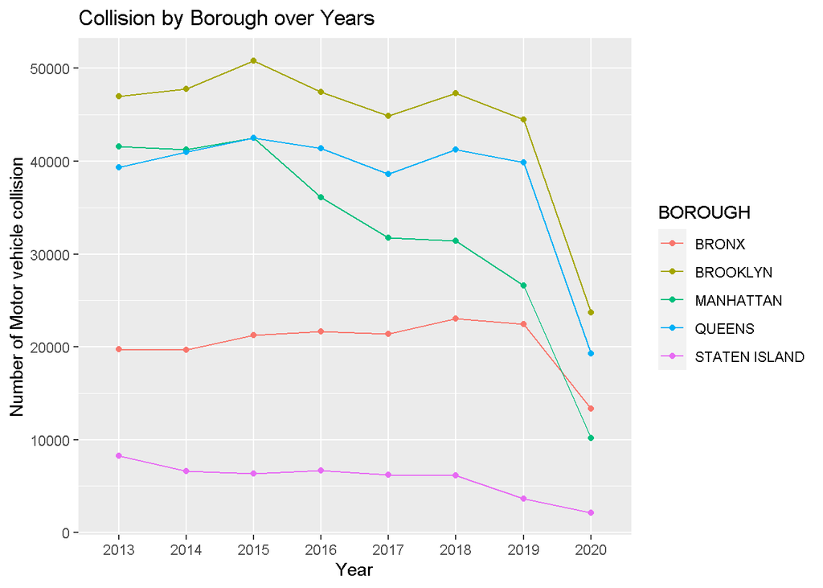

```r
ggplot(borough, aes(x = Year, y = freq,group=BOROUGH,colour=BOROUGH)) +geom_point()+geom_line()+
  labs(x = "Year", y = "Number of Motor vehicle collision",
              title = "Collision by Borough over Years")
```

The graph indicates Brooklyn has the highest collision number and Staten Island has the lowest number. From year 2013 to 2020, there is a decrease collision number for all boroughs. Among this five boroughs, Manhattan’s collision number decrease sharply since year 2015.

## Total Collision number

What is the collision rate in NYC from 2013 to 2020?

```r
YearNumber<-motor %>%
          select(Year)%>%
          filter(Year > '2012' )%>%
          group_by(Year)%>%
          count()

YearNumber
```

| Year | freq |
| --- | --- |
| 2013 | 203734 |
| 2014 | 206033 |
| 2015 | 217694 |
| 2016 | 229830 |
| 2017 | 231007 |
| 2018 | 231563 |
| 2019 | 211481 |
| 2020 | 105098 |

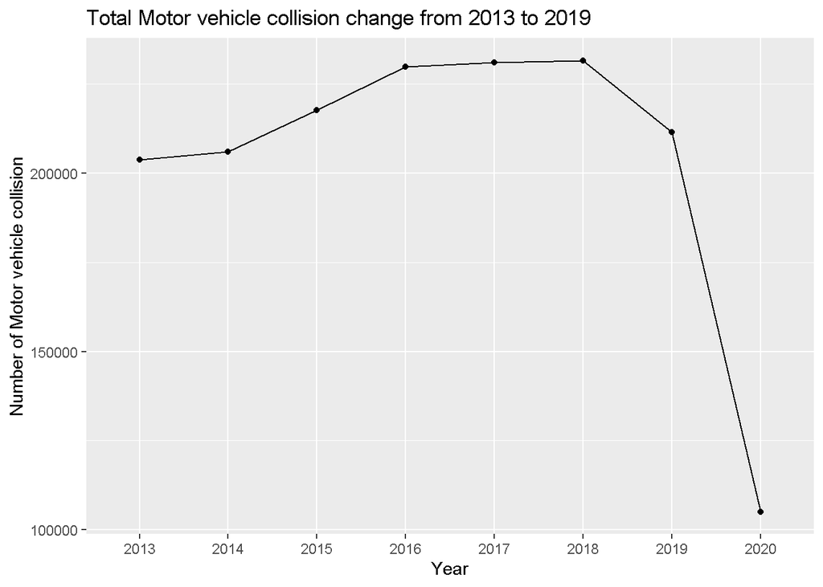

```r
ggplot(YearNumber, aes(x = Year, y = freq,group=1)) +geom_point()+geom_line()+
  labs(x = "Year", y = "Number of Motor vehicle collision",
              title = "Total Motor vehicle collision change from 2013 to 2019")
```

## Collisions by Month

```r
MonthNumber<-motor %>%
          filter(Year > '2012')%>%
          select(Month)%>%
          group_by(Month)%>%
          count()

MonthNumber
```

| Month | freq |
| --- | --- |
| 01 | 133432 |
| 02 | 123418 |
| 03 | 136542 |
| 04 | 125152 |
| 05 | 143817 |
| 06 | 145465 |
| 07 | 140765 |
| 08 | 138335 |
| 09 | 138791 |
| 10 | 143797 |

[output cut: 2 more lines]

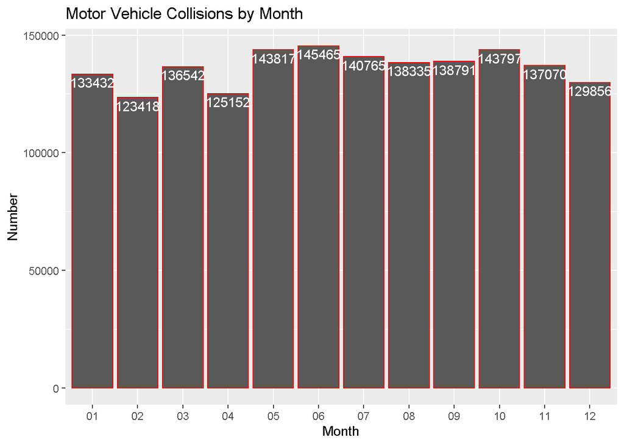

```r
ggplot(MonthNumber, aes(x=Month, y=freq)) +
    geom_bar(stat="identity", position=position_dodge(), colour="red", width = 0.9) +
    ggtitle("Motor Vehicle Collisions by Month") +
    xlab("Month") + ylab("Number") +geom_text(aes(label = freq), vjust = 1.3, colour = "white")
```

May, June and October has the highest collision number. New York has a long winter and People start joining outside activities in May and June.

## Collisions by Hour

```r
#separate the crash time to Hour and Min
time <- separate(motor, 'CRASH TIME', c("Hour", "min"))
head(time)
```

| Month | Day | Year | Hour | min | BOROUGH | ZIP CODE | LATITUDE | LONGITUDE | LOCATION | ON STREET NAME | CROSS STREET NAME | OFF STREET NAME | NUMBER OF PERSONS INJURED | NUMBER OF PERSONS KILLED | NUMBER OF PEDESTRIANS INJURED | NUMBER OF PEDESTRIANS KILLED | NUMBER OF CYCLIST INJURED | NUMBER OF CYCLIST KILLED | NUMBER OF MOTORIST INJURED | NUMBER OF MOTORIST KILLED | CONTRIBUTING FACTOR VEHICLE 1 | CONTRIBUTING FACTOR VEHICLE 2 | CONTRIBUTING FACTOR VEHICLE 3 | CONTRIBUTING FACTOR VEHICLE 4 | CONTRIBUTING FACTOR VEHICLE 5 | COLLISION_ID | VEHICLE TYPE CODE 1 | VEHICLE TYPE CODE 2 | VEHICLE TYPE CODE 3 | … |
| --- | --- | --- | --- | --- | --- | --- | --- | --- | --- | --- | --- | --- | --- | --- | --- | --- | --- | --- | --- | --- | --- | --- | --- | --- | --- | --- | --- | --- | --- | --- |
| 12 | 04 | 2020 | 16 | 55 |  | NA | NA | NA |  | WILLIAMSBURG BRIDGE OUTER ROADWA |  |  | 0 | 0 | 0 | 0 | 0 | 0 | 0 | 0 | Reaction to Uninvolved Vehicle | Driver Inattention/Distraction |  |  |  | 4373202 | Sedan | Sedan |  | … |
| 12 | 04 | 2020 | 9 | 16 |  | NA | NA | NA |  | TRIBOROUGH BRIDGE |  |  | 0 | 0 | 0 | 0 | 0 | 0 | 0 | 0 | Reaction to Uninvolved Vehicle | Unsafe Speed |  |  |  | 4373670 | Sedan |  |  | … |
| 12 | 03 | 2020 | 13 | 37 |  | NA | 40.79850 | -73.96712 | (40.798504, -73.967125) | WEST 103 STREET |  |  | 1 | 0 | 1 | 0 | 0 | 0 | 0 | 0 |  |  |  |  |  | 4373072 |  |  |  | … |
| 12 | 03 | 2020 | 9 | 05 |  | NA | NA | NA |  | TRIBOROUGH BRIDGE |  |  | 0 | 0 | 0 | 0 | 0 | 0 | 0 | 0 | Unspecified |  |  |  |  | 4372904 | Sedan |  |  | … |
| 12 | 02 | 2020 | 13 | 29 |  | NA | NA | NA |  | CHURCH AVENUE | OCEAN PARKWAY |  | 1 | 0 | 1 | 0 | 0 | 0 | 0 | 0 | Unspecified |  |  |  |  | 4373367 | Bus |  |  | … |
| 12 | 02 | 2020 | 19 | 00 |  | NA | 40.73117 | -73.70994 | (40.731167, -73.70994) | 256 STREET | 87 AVENUE |  | 0 | 0 | 0 | 0 | 0 | 0 | 0 | 0 | Unspecified |  |  |  |  | 4372881 | Taxi |  |  | … |

```r
TimeNumber<-time %>%
          select(Hour)%>%
          group_by(Hour)%>%
          arrange(Hour)%>%
          count()

# Change the data type of Hour to number and then sort the number
TimeNumber$Hour<-as.integer(as.character(TimeNumber$Hour))
TimeNumber<-TimeNumber%>%
            arrange(Hour)

TimeNumber
```

| Hour | freq |
| --- | --- |
| 0 | 51656 |
| 1 | 27748 |
| 2 | 21006 |
| 3 | 18215 |
| 4 | 20950 |
| 5 | 23186 |
| 6 | 37113 |
| 7 | 51270 |
| 8 | 96850 |
| 9 | 94672 |

[output cut: 14 more lines]

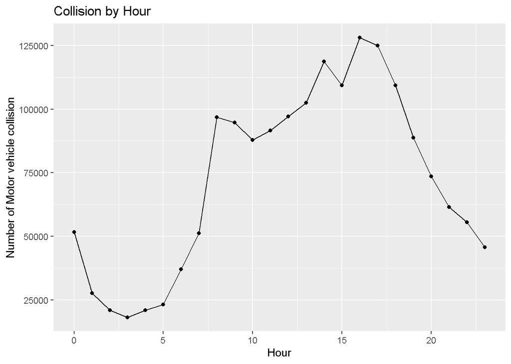

```r
ggplot(TimeNumber, aes(x = Hour, y = freq,group=1)) +geom_point()+geom_line()+
  labs(x = "Hour", y = "Number of Motor vehicle collision",
              title = "Collision by Hour")
```

The peak time has the highest collision number, especially during 4PM to 6PM. 3AM has the lowest collision rate for a whole day.

## Causes of Motor Vehicle Collisions

```r
reason<-motor %>%
          select('CONTRIBUTING FACTOR VEHICLE 1')%>%
          group_by('CONTRIBUTING FACTOR VEHICLE 1')%>%
          filter( 'CONTRIBUTING FACTOR VEHICLE 1'!="NA")%>%
          count

reason_count <-count(reason, "CONTRIBUTING.FACTOR.VEHICLE.1")
```

```
## Using freq as weighting variable
```

```r
reason_count<-reason_count[order(reason_count$freq, decreasing = T),]
reason_count
```

|  | CONTRIBUTING.FACTOR.VEHICLE.1 | freq |
| --- | --- | --- |
| 58 | Unspecified | 624121 |
| 13 | Driver Inattention/Distraction | 332243 |
| 20 | Failure to Yield Right-of-Way | 99925 |
| 23 | Following Too Closely | 89136 |
| 8 | Backing Unsafely | 66240 |
| 34 | Other Vehicular | 54931 |
| 21 | Fatigued/Drowsy | 47003 |
| 55 | Turning Improperly | 43576 |
| 38 | Passing or Lane Usage Improper | 42858 |
| 39 | Passing Too Closely | 39284 |

[output cut: 52 more lines]

The top Contributing factor is Unspecified and it is not a real reason. I will drop Unspecified reason and Choose the other top 10 factors.

```r
#Drop Unspecified reason
reason_count<-reason_count%>%
              filter(freq>=33844 & freq<624121)
```

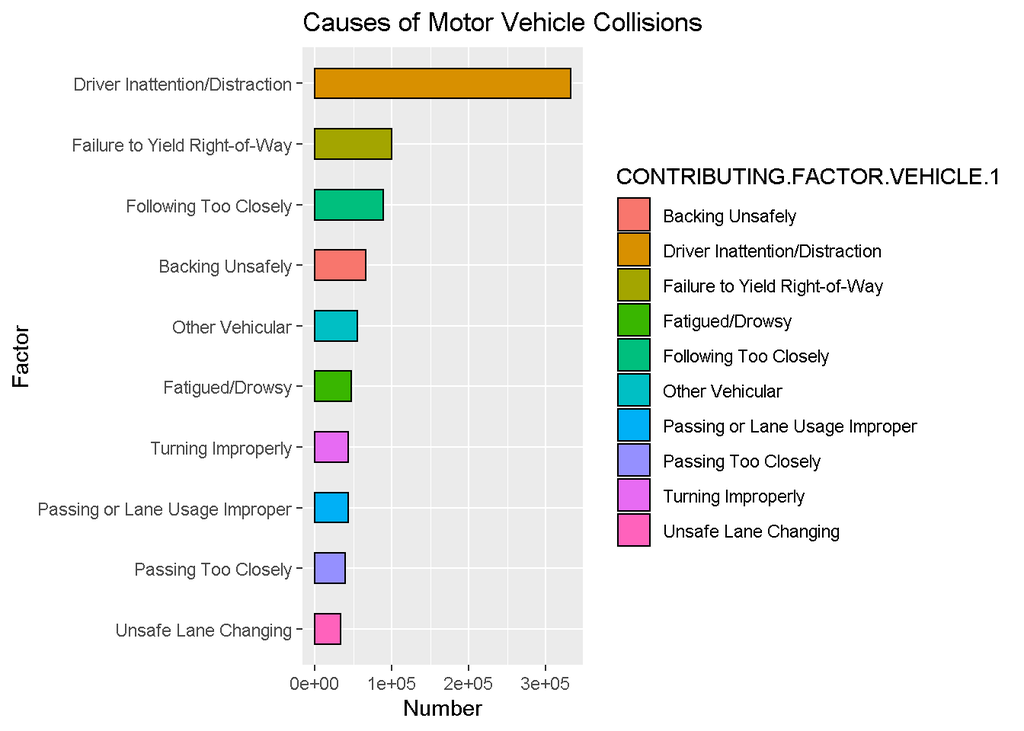

```r
ggplot(reason_count, aes(reorder(CONTRIBUTING.FACTOR.VEHICLE.1,freq), y=freq,fill=CONTRIBUTING.FACTOR.VEHICLE.1)) +
    geom_bar(stat="identity", position=position_dodge(), colour="black", width = 0.5) +coord_flip()+
    ggtitle("Causes of Motor Vehicle Collisions") +
    xlab("Factor") + ylab("Number")
```

There are many reasons for the accidents. Driver inattention/Distraction is the #1 reason for the accident during those years. Failure to Yield Right of way and Following too closely are the other two reasons for accidents.Drivers need to pay more attention behind the wheel.

## Map

Using all the latitude and longitude data, I first create a map to mark all the location of the collisions. You can check the code and map by clicking this link.

https://github.com/DaisyCai2019/Data608/blob/master/Final%20Project/Motor_vehicle%20Collision%20Map.ipynb

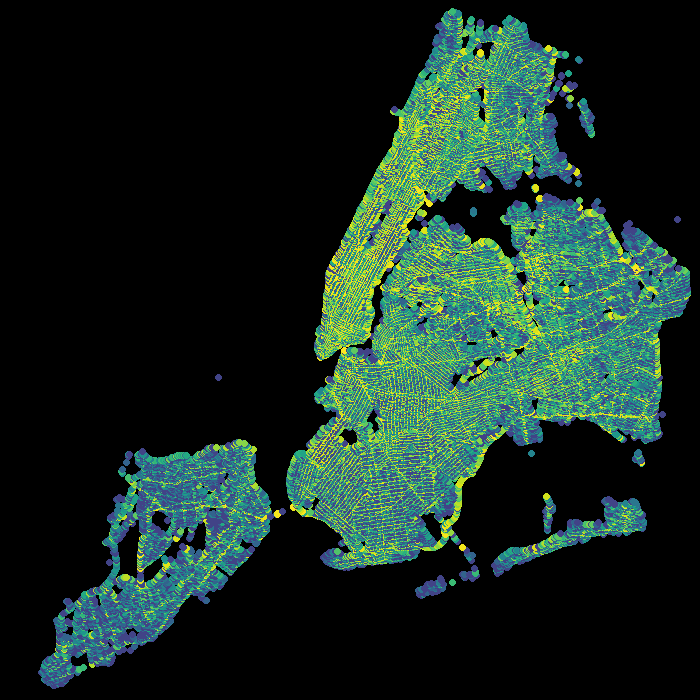

```r
knitr::include_graphics("Map.png")
```

From the map, we notice that Manhattan, Bronx and north side of Queens have more collisions than other areas. We also find out some interesting yellow spots along the sea.

## Shiny APP

Shiny App shows the collision data by Borough and also the collision location by year(2015-2020).

https://daisycai.shinyapps.io/Data608_Final/

# Conclusion